# House Selling Prices

Devin Harp

December 14, 2022

The purpose of this analysis is to predict a house’s selling price (Sales Price) with a model created from the sea of potential variables present. The goal is to get a high enough validated $R^2$ while maintaining interpretability of the model.

### Model & Validation

Variables of interest after diagnosing a humongous pairs plot are those with separated square foot area, neighborhood, and overall quality given by a real estate agent.

To start off, the separate variables dictating square footage of space for the property were combined to create a total and specific neighborhoods were separated in various levels of economic class (poor, middle, and rich). Lastly, we utilized a marketer’s judgment on quality for each property as a useful predictor like how Brother Saunder’s magic two groups was helpful for predicting final exam scores.

Our model can be written as so:

$$Y_i = \overbrace{\beta_0 + \beta_1 X_{1i} + \beta_2 X_{2i} + \beta_3
X_{1i} X_{4i} + \beta_4 X_{1i} X_{3i}}^\text{HD Model} + \epsilon_i$$

```r
set.seed(121)

num_rows <- 1000 #1460 total
keep <- sample(1:nrow(train), num_rows)

mytrain <- train[keep, ] #Use this in the lm(..., data=mytrain)

mytest <- train[-keep, ] #Use this in the predict(..., newdata=mytest)

house.lm <- lm(SalePrice ~ TotalSF + TotalSF:RichNbrhd + OverallQual + TotalSF:OverallQual, data = mytrain)
pander(summary(house.lm))
```

|  | Estimate | Std. Error | t value | Pr(>\|t\|) |
| --- | --- | --- | --- | --- |
| **(Intercept)** | 130719 | 12291 | 10.64 | 4.283e-25 |
| **TotalSF** | -38.84 | 4.936 | -7.868 | 9.353e-15 |
| **OverallQual** | -12832 | 2050 | -6.261 | 5.687e-10 |
| **TotalSF:RichNbrhd** | 7.41 | 0.7714 | 9.606 | 5.927e-21 |
| **TotalSF:OverallQual** | 12.96 | 0.7209 | 17.97 | 9.163e-63 |

Fitting linear model: SalePrice ~ TotalSF + TotalSF:RichNbrhd + OverallQual + TotalSF:OverallQual

| Observations | Residual Std. Error | $R^2$ | Adjusted $R^2$ |
| --- | --- | --- | --- |
| 1000 | 30062 | 0.8635 | 0.8629 |

```r
b <- coef(house.lm)
```

Rich neighborhoods were originally significant but with the introductino of overall quality, the p value rose above the level of significance of 0.05. Keeping the slope interaction term however maintained its relevancy so accordingly which makes sense.

### Graphs

Due to the nature of the HD model, many interactions exist and the following graphs attempt to better illustrate the possible combinations.

The first graph is meant to give an overview of the data using colors and shapes to display the relations. For class, 0 stands for poor neighborhoods, 1 for middle class, and 2 for rich. Overall quality goes from the standard 1 to 10 rating. Interestingly, we don’t see many rich neighborhood properties topping the total square footage, but being more middle ground but striking a higher price tag. We see a strong trend of a unified exponential growth overall in the data but when broken down by individual characteristics, it appears more linear.

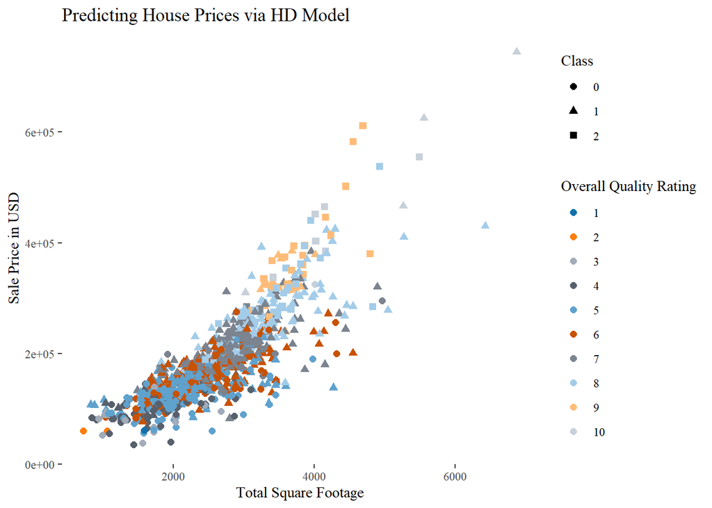

```r
ggplot(mytrain, aes(x = TotalSF, y = SalePrice, color = as.factor(OverallQual), shape = as.factor(RichNbrhd))) +
  geom_point(size = 2) +
  scale_color_tableau('Color Blind') +
  labs(x = 'Total Square Footage', y = 'Sale Price in USD', title = 'Predicting House Prices via HD Model', color = 'Overall Quality Rating', shape = 'Class') +
  theme_tufte()
```

```r
# For color mapping in next graph
col <- as.character(hue_pal()(22)) %>% as_tibble()
```

The following graph emphasizes the interaction between Overall Quality and the neighborhood. The first number in the interaction is the quality ranking and the second is the neighborhood class (As a reminder, 0 = Poor, 1 = Middle, 2 = Rich). A few of the dozen possible relationships were selected for interpretation via regression. What is interesting is that rich neighborhoods never go below a quality ranking of 6 and middle class neighborhood never go below 3. Poorer neighborhoods exhibit all possible quality rankings.

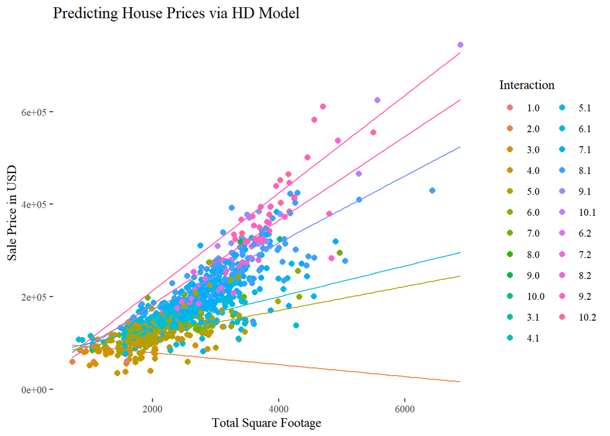

```r
ggplot(mytrain, aes(x = TotalSF, y = SalePrice, color = interaction(OverallQual, RichNbrhd))) +
  geom_point(size = 2) +
  stat_function(fun = function(TotalSF, OverallQual = 10, RichNbrhd = 2) b[1] + b[2] * TotalSF + b[3] * OverallQual + b[4] * TotalSF * RichNbrhd + b[5] * TotalSF * OverallQual, color = col$value[21]) +
  stat_function(fun = function(TotalSF, OverallQual = 8, RichNbrhd = 1) b[1] + b[2] * TotalSF + b[3] * OverallQual + b[4] * TotalSF * RichNbrhd + b[5] * TotalSF * OverallQual, color = col$value[16]) +
  stat_function(fun = function(TotalSF, OverallQual = 5, RichNbrhd = 1) b[1] + b[2] * TotalSF + b[3] * OverallQual + b[4] * TotalSF * RichNbrhd + b[5] * TotalSF * OverallQual, color = col$value[13]) +
  stat_function(fun = function(TotalSF, OverallQual = 10, RichNbrhd = 0) b[1] + b[2] * TotalSF + b[3] * OverallQual + b[4] * TotalSF * RichNbrhd + b[5] * TotalSF * OverallQual, color = col$value[21]) +
  stat_function(fun = function(TotalSF, OverallQual = 5, RichNbrhd = 0) b[1] + b[2] * TotalSF + b[3] * OverallQual + b[4] * TotalSF * RichNbrhd + b[5] * TotalSF * OverallQual, color = col$value[5]) +
  stat_function(fun = function(TotalSF, OverallQual = 2, RichNbrhd = 0) b[1] + b[2] * TotalSF + b[3] * OverallQual + b[4] * TotalSF * RichNbrhd + b[5] * TotalSF * OverallQual, color = col$value[2]) +
  labs(x = 'Total Square Footage', y = 'Sale Price in USD', title = 'Predicting House Prices via HD Model', color = 'Interaction', shape = 'Class') +
  theme_tufte()
```

### Interpretation & Validation

*Statistics summary table below for reference.*

```r
pander(summary(house.lm))
```

|  | Estimate | Std. Error | t value | Pr(>\|t\|) |
| --- | --- | --- | --- | --- |
| **(Intercept)** | 130719 | 12291 | 10.64 | 4.283e-25 |
| **TotalSF** | -38.84 | 4.936 | -7.868 | 9.353e-15 |
| **OverallQual** | -12832 | 2050 | -6.261 | 5.687e-10 |
| **TotalSF:RichNbrhd** | 7.41 | 0.7714 | 9.606 | 5.927e-21 |
| **TotalSF:OverallQual** | 12.96 | 0.7209 | 17.97 | 9.163e-63 |

Fitting linear model: SalePrice ~ TotalSF + TotalSF:RichNbrhd + OverallQual + TotalSF:OverallQual

| Observations | Residual Std. Error | $R^2$ | Adjusted $R^2$ |
| --- | --- | --- | --- |
| 1000 | 30062 | 0.8635 | 0.8629 |

When the total square footage, overall quality are at 0 in a poor neighborhood, we have a mean sale price of $130,719. Perfectly reasonable for a small piece of cardboard in California. In all seriousness, that’s not exactly meaningful or sensible no matter how bad the housing market is right now.

The value of a home is heavily determined by the combination of the total square footage and the interaction of the neighborhood its in and interaction with the overall quality. TotalSF gains $12.96 per square foot in value for each extra point achieved in the OverallQual variable and $7.41 for each a gain in neighborhood wealth class. If the overall quality is 0 and its in a poor neighborhood, the home depreciates by roughly $38.84. So for a home with an overall quality ranking of 10 and in a rich neighborhood with a total square footage of 6000, we ought to see a sales price of $635,724.40. On the previous graph showing some of the relationships, this roughly matches what we see. For a house with a quality ranking of 2 in a poor neighborhood with a total square footage of, let’s say 1000, we get a sales price of $92,131.68. Perfect for a recent college graduate right? Don’t mind the mice or people breaking in.

```r
yht <- predict(house.lm, newdata = mytest)

ybar <- mean(mytest$SalePrice)

SSTO <- sum( (mytest$SalePrice - ybar)^2 )

SSE <- sum( (mytest$SalePrice - yht)^2 )

rsq <- 1 - SSE/SSTO

n <- length(mytest$SalePrice)

pm <- length(coef(house.lm))

rsq2 <- 1 - (n - 1)/(n - pm) * SSE/SSTO

my_output_table2 <- data.frame(Model = "My Model", `Original R2` = summary(house.lm)$r.squared, `Orig. Adj. R-squared` = summary(house.lm)$adj.r.squared, `Validation R-squared` = rsq, `Validation Adj. R^2` = rsq2)

colnames(my_output_table2) <- c("Model", "Original $R^2$", "Original Adj. $R^2$", "Validation $R^2$", "Validation Adj. $R^2$")

knitr::kable(my_output_table2, escape = TRUE, digits = 4)
```

| Model | Original $R^2$ | Original Adj. $R^2$ | Validation $R^2$ | Validation Adj. $R^2$ |
| --- | --- | --- | --- | --- |
| My Model | 0.8635 | 0.8629 | 0.8655 | 0.8644 |

The model maintains a respectable R2 and adjusted R2 throughout the validation process. 86% of the variance in the data can be explained by my model which is decent for a real world application.